# Assignment 3

Note: Worked with Janice Luong, Chad Pickering, Ricky Safran, Nivi Achanta, Hannah Kosinovsky, and used a lot of stackoverflow resources

The US Department of Agriculture publishes price estimates for fruits and vegetables [online](https://www.ers.usda.gov/data-products/fruit-and-vegetable-prices/fruit-and-vegetable-prices/). The most recent estimates are based on a 2013 survey of US retail stores.

The estimates are provided as a collection of MS Excel files, with one file per fruit or vegetable. The `assignment3_data.zip` file contains the fruit and vegetable files in the directories `fruit` and `vegetables`, respectively.

**Exercise 1.1.** Use pandas to extract the "Fresh" row(s) from the **fruit** Excel files. Combine the data into a single data frame. Your data frame should look something like this:

| type | food | form | price_per_lb | yield | lb_per_cup | price_per_cup |
| --- | --- | --- | --- | --- | --- | --- |
| fruit | watermelon | Fresh1 | 0.333412 | 0.52 | 0.330693 | 0.212033 |
| fruit | cantaloupe | Fresh1 | 0.535874 | 0.51 | 0.374786 | 0.3938 |
| vegetables | onions | Fresh1 | 1.03811 | 0.9 | 0.35274 | 0.406868 |
| ... |  |  |  |  |  |  |

It's okay if the rows and columns of your data frame are in a different order. These modules are especially relevant:

- [`str` methods](https://docs.python.org/2/library/stdtypes.html#string-methods)
- [`os`](https://docs.python.org/2/library/os.html)
- [`os.path`](https://docs.python.org/2/library/os.path.html)
- [pandas](http://pandas.pydata.org/pandas-docs/stable/): `read_excel()`, `concat()`, `.fillna()`, `.str`, plotting methods

Ask questions and search the documentation/web to find the functions you need.

```python
import os
import os.path
import pandas as pd

#get a list of the files in the fruit folder given to us
fruit_names = [x for x in os.listdir("fruit") if x.endswith("xlsx")]

#list of column names to be used later (dictated by the table above)
column_name=['type','food','form','price_per_lb', 'yield','lb_per_cup','price_per_cup']

#takes in the food_name and a file name and returns a data frame of 1 row and 6 column
def extract_fresh(food_name, fname):
    file_name = food_name+"/"+str(fname)
    panda_file = pd.read_excel(file_name)
    if panda_file.loc[2][0].find("Fresh") == 0:
        row = list()
        row.append(file_name.split('/')[0]) #gets the type
        row.append(fname.split('.')[0]) #gets the food
        row.append(panda_file.loc[2][0]) #gets the form
        row.append(panda_file.loc[2][1]) #gets the price_per_pounf
        row.append(panda_file.loc[2][3]) #gets the yield
        row.append(panda_file.loc[2][4]) #gets the lb_per_cup
        row.append(panda_file.loc[2][6]) #gets the price_per_cup
        row_df = pd.DataFrame([row], columns = column_name) #creates a df with the above info and the column names from above
        return row_df

fresh_fruit_df = [extract_fresh("fruit",x) for x in fruit_names] #returns a list of seperate data frames(one for each fruit file)
fresh_fruit_df = pd.concat(fresh_fruit_df)
fresh_fruit_df.head()
```

|  | type | food | form | price_per_lb | yield | lb_per_cup | price_per_cup |
| --- | --- | --- | --- | --- | --- | --- | --- |
| 0 | fruit | apples | Fresh1 | 1.567515 | 0.90 | 0.242508 | 0.422373 |
| 0 | fruit | apricots | Fresh1 | 3.040072 | 0.93 | 0.363763 | 1.189102 |
| 0 | fruit | bananas | Fresh1 | 0.566983 | 0.64 | 0.330693 | 0.292965 |
| 0 | fruit | blackberries | Fresh1 | 5.774708 | 0.96 | 0.319670 | 1.922919 |
| 0 | fruit | blueberries | Fresh1 | 4.734622 | 0.95 | 0.319670 | 1.593177 |

**Exercise 1.2.** Reuse your code from exercise 1.1 to extract the "Fresh" row(s) from the **vegetable** Excel files.

Does your code produce the correct prices for tomatoes? If not, why not? Do any other files have the same problem as the tomatoes file?

You don't need to extract the prices for these problem files. However, make sure the prices are extracted for files like asparagus that don't have this problem.

```python
#gets a list of all the files in the vegetable folder
veggie_names = [x for x in os.listdir("vegetables") if x.endswith("xlsx")]

fresh_veggie_df = [extract_fresh("vegetables",x) for x in veggie_names] #returns a list of seperate data frames - one for each fruit file
fresh_veggie_df = pd.concat(fresh_veggie_df)
fresh_veggie_df.head()
```

|  | type | food | form | price_per_lb | yield | lb_per_cup | price_per_cup |
| --- | --- | --- | --- | --- | --- | --- | --- |
| 0 | vegetables | acorn_squash | Fresh1 | 1.17225 | 0.458554 | 0.451948 | 1.155360 |
| 0 | vegetables | artichoke | Fresh1 | 2.21305 | 0.375309 | 0.385809 | 2.274967 |
| 0 | vegetables | asparagus | Fresh1 | 3.21349 | 0.493835 | 0.396832 | 2.582272 |
| 0 | vegetables | avocados | Fresh1 | 2.23587 | 0.740753 | 0.31967 | 0.964886 |
| 0 | vegetables | broccoli | Fresh |  |  |  | NaN |

No, my code was unable to produce the correct price for the tomatoes file (as well as files similar to it). My function works by looking at the third row of each file and picking the information out of that. In the case of the tomato file, the third row does not include the information but rather the information is dropped down into the next rows so the multiple varieties of fresh tomatoes are listed (i.e grape and cherry, roma, and beefsteak tomatoes).

Other vegetables with the same issue are broccoli, carrots, cauliflower, celery, lettuce_romaine, mushrooms, and spinach.

**Exercise 1.3.** Remove rows without a price from the vegetable data frame and then combine the fruit and vegetable data frames. Make sure all columns of numbers are numeric (not strings).

```python
fresh_df = pd.concat([fresh_fruit_df, fresh_veggie_df])
fresh_df = fresh_df.dropna()
fresh_df.head()
```

|  | type | food | form | price_per_lb | yield | lb_per_cup | price_per_cup |
| --- | --- | --- | --- | --- | --- | --- | --- |
| 0 | fruit | apples | Fresh1 | 1.56752 | 0.9 | 0.242508 | 0.422373 |
| 0 | fruit | apricots | Fresh1 | 3.04007 | 0.93 | 0.363763 | 1.189102 |
| 0 | fruit | bananas | Fresh1 | 0.566983 | 0.64 | 0.330693 | 0.292965 |
| 0 | fruit | blackberries | Fresh1 | 5.77471 | 0.96 | 0.31967 | 1.922919 |
| 0 | fruit | blueberries | Fresh1 | 4.73462 | 0.95 | 0.31967 | 1.593177 |

```python
[type(fresh_df.iloc[0][x]) for x in column_name]
```

```
[str, str, unicode, float, float, float, numpy.float64]
```

All columns of numbers are numeric (aka they are all floats).

**Exercise 1.4.** Discuss the questions below (a paragraph each is sufficient). Use plots to support your ideas.

- What kinds of fruits are the most expensive (per pound)? What kinds are the least expensive?
- How do the price distributions compare for fruit and vegetables?
- Which foods are the best value for the price?
- What's something surprising about this data set?
- Which foods do you expect to provide the best combination of price, yield, and nutrition? A future assignment may combine this data set with another so you can check your hypothesis.

**What kinds of fruits are the most expensive (per pound)? What kinds are the least expensive?**

```python
import matplotlib.pyplot as plt
import seaborn as sns
import numpy as np
```

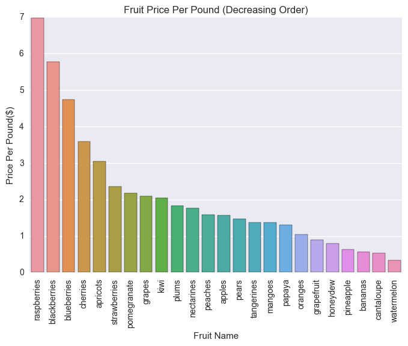

```python
## Made a barplot that arranges the fruit from most expensive to least expensive

# Returns rows with "fruit"
fruit_df = fresh_df.loc[fresh_df['type'] == "fruit"]

#sort the fruit by price_per_lb column
sorted_fruit = fruit_df.sort_values(by = fruit_df.columns[3], ascending = False)

#create bar plot with food and price
fruit_bar = sns.barplot(x = "food", y = "price_per_lb", data = sorted_fruit)
#turns the fruit names on the x-axis so that they are readable
for item in fruit_bar.get_xticklabels():
    item.set_rotation(90)
#renaming the plot and changing the y and x labels for the axes
sns.plt.title('Fruit Price Per Pound (Decreasing Order)')
fruit_bar.set(ylabel = 'Price Per Pound($)', xlabel = 'Fruit Name')
sns.plt.show() #displaying the plot
```

The three most expensive fruits are raspberries, blackberries, and blueberries. The three least expensive fruits are bananas, cantaloupe, and watermelon. It seems that berries and other small fruits are more expensive than the larger fruits and melons. This suprised me because I would think that more seasonal fruits (like watermelon or cantaloupe) would be more expensive because they are only available during specific months of the year.

**How do the price distributions compare for fruit and vegetables?**

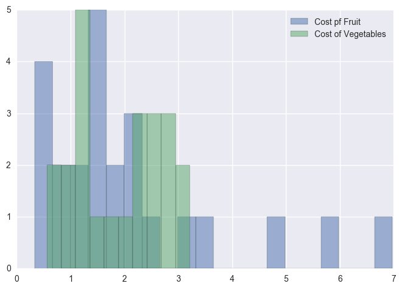

```python
##create two overlapping historgrams to look at the distributions of both the fruit and veggies at the same time

veggie_df = fresh_df.loc[fresh_df['type'] == "vegetables"] #creating a df with just veggies (matching my just fruit one)

plt.hist(fruit_df['price_per_lb'],bins=20,alpha=.5,label='Cost pf Fruit') #plotting the histogram for fruits
plt.hist(veggie_df['price_per_lb'],bins=10,alpha=.5,label='Cost of Vegetables') #plotting the histogram for veggies
plt.legend()
plt.show()
```

This plot displays two histograms overlayed on each other. The mean price per pound of vegetables seems to be a little bit higher than that of the fruit. But, the variance for fruit is much larger than that for vegetables. This makes sense because of the wide range of prices that we saw in the previous graph were fairly spread out. I'm sure that if we plotted the same graph for veggies, we would see a much smaller range of prices.

**Which foods are the best value for the price?**

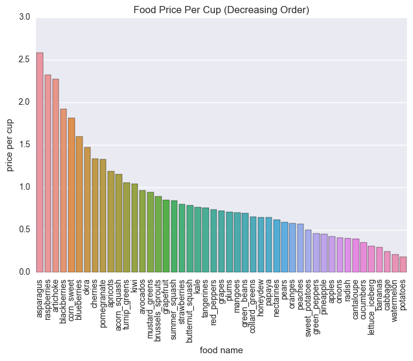

```python
##Plotted a bar graph of all the price per cups for all food(fruit AND veggies) in decreasing order

#sort the food (fruit and veggies) by price per cup column
sorted_food = fresh_df.sort_values(by = fresh_df.columns[6], ascending = False)

#create bar plot with food and price
food_bar = sns.barplot(x = "food", y = "price_per_cup", data = sorted_food)
#turns the fruit names on the x-axis so that they are readable
for item in food_bar.get_xticklabels():
    item.set_rotation(90)
#renaming the plot and changing the y and x labels for the axes
sns.plt.title('Food Price Per Cup (Decreasing Order)')
food_bar.set(ylabel = 'price per cup', xlabel = 'food name')
sns.plt.show() #displaying the plot
```

**What's something surprising about this data set?**

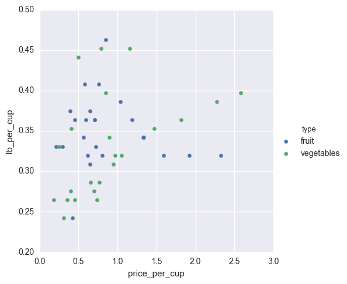

```python
#plotted a scatterplot to show the relationship between price per cup ad pound per cup that distinguishes the type of food
#by the color of the points

facets = sns.FacetGrid(fresh_df, hue = "type", size = 5) #the color is based on the type of food (either veggie or fruit)
facets.map(plt.scatter, "price_per_cup", "lb_per_cup").add_legend()
plt.show()
```

Something interesting about this data is seen when you compare the price per cup and the pounds per cup. When you look at the relationship between the variables for vegetables,there is a slight positive relationship. This means that as the number of pounds per cup go up, the price per cup also goes up. That is to be predicted, but the interesting part of this data comes when you look at the same relationship for fruit. The relationship between pound per cup and price per cup is unclear. This means that fruits do not need to weigh more to cost more. This unclear relationship makes it difficult to determine where the price is coming from because if it is not coming from the weight of the food, it must be coming from somewhere else.

**Which foods do you expect to provide the best combination of price, yield, and nutrition?** (A future assignment may combine this data set with another so you can check your hypothesis.)

The foods that I expect to provide the best combination of price and yield are those that have a moderately high yield because those are the types of food that have low prices because they are presumably not a luxury food if the yield is high. But, due to the fact that the type of "nutrition" is not specified, it is hard to determine what foods would be have an abundant yield, the most nutritients, and the most budget friendly. I am sure there is a way to weight those three variables (once we know the nutrition variable) and come up with the foods that are the best combination of the three but at the moment, I don't know what food would balance all three.